# AIML Online Capstone - AUTOMATIC TICKET ASSIGNMENT

## Interim Report Submission

## 1: Summary of problem statement

**In the support process, incoming incidents are analyzed and assessed by organization’s support teams to fulfill the request.**

In many organizations, better allocation and effective usage of the valuable support resources will directly result in substantial cost savings.

**Currently the incidents are created by various stakeholders (Business Users, IT Users and Monitoring Tools) within IT Service Management Tool and are assigned to Service Desk teams (L1 / L2 teams).**

This team will review the incidents for right ticket categorization, priorities and then carry out initial diagnosis to see if they can resolve. Around ~54% of the incidents are resolved by L1 / L2 teams. Incase L1 / L2 is unable to resolve, they will then escalate / assign the tickets to Functional teams from Applications and Infrastructure (L3 teams).

**Some portions of incidents are directly assigned to L3 teams by either Monitoring tools or Callers / Requestors.** L3 teams will carry out detailed diagnosis and resolve the incidents. Around ~56% of incidents are resolved by Functional / L3 teams. Incase if vendor support is needed, they will reach out for their support towards incident closure. L1 / L2 needs to spend time reviewing Standard Operating Procedures (SOPs) before assigning to Functional teams (Minimum ~25-30% of incidents needs to be reviewed for SOPs before ticket assignment).

**15 min is being spent for SOP review for each incident. Minimum of ~1 FTE effort needed only for incident assignment to L3 teams.**

## Objective Of the Project

**In this capstone project, the goal is to build a classifier that can classify the tickets by analyzing text, Guided by powerful AI techniques that can classify incidents to right functional groups can help organizations to reduce the resolving time of the issue and can focus on more productive tasks.**

## Preparing the Environment and Loading the Library for Analysis and Modeling

import tensorflow as tf

```python
!pip install langdetect
```

```
     |████████████████████████████████| 983kB 5.2MB/s
```

```python
# install googletrans using pip
!pip install googletrans
```

```
     |████████████████████████████████| 61kB 3.1MB/s
     |████████████████████████████████| 972kB 7.0MB/s
     |████████████████████████████████| 51kB 6.4MB/s
     |████████████████████████████████| 61kB 7.4MB/s
     |████████████████████████████████| 71kB 8.0MB/s
     |████████████████████████████████| 102kB 11.1MB/s
```

```python
!pip install ftfy
```

```
     |████████████████████████████████| 71kB 3.4MB/s
```

```python
!pip install wordcloud
```

```python
!pip install nltk
```

```python
from  google.colab import drive
import os

import numpy as np
import pandas as pd
import matplotlib.pyplot as plt

import seaborn as sns

import googletrans
from googletrans import Translator

import re
from langdetect import detect
from ftfy import fix_text
from ftfy.badness import sequence_weirdness
from wordcloud import WordCloud, STOPWORDS
```

```python
import nltk
from nltk.corpus import stopwords
from nltk.stem import PorterStemmer
import re
from nltk.stem import WordNetLemmatizer
from nltk.corpus import wordnet
nltk.download('stopwords')
stop = set(stopwords.words('english'))
nltk.download('punkt')
nltk.download('averaged_perceptron_tagger')
nltk.download('wordnet')
```

```
True
```

## 2: Summary of Data and Findings, EDA and Pre-processing

### Loading the Data from the Given Dataset

```python
drive.mount("/content/drive")
```

```python
os.chdir('/content/drive/My Drive/AIML/GreatLearning/Capstone/')
```

```python
input_data  = pd.read_excel('input_data.xlsx')
input_data.head()  # view the first 5 rows of the data
```

|  | Short description | Description | Caller | Assignment group |
| --- | --- | --- | --- | --- |
| 0 | login issue | -verified user details.(employee# & manager na... | spxjnwir pjlcoqds | GRP_0 |
| 1 | outlook | \r\n\r\nreceived from: hmjdrvpb.komuaywn@gmail... | hmjdrvpb komuaywn | GRP_0 |
| 2 | cant log in to vpn | \r\n\r\nreceived from: eylqgodm.ybqkwiam@gmail... | eylqgodm ybqkwiam | GRP_0 |
| 3 | unable to access hr_tool page | unable to access hr_tool page | xbkucsvz gcpydteq | GRP_0 |
| 4 | skype error | skype error | owlgqjme qhcozdfx | GRP_0 |

## Dataset Information

```python
input_data.shape
```

```
(8500, 4)
```

```python
input_data.info()
```

```
<class 'pandas.core.frame.DataFrame'>
RangeIndex: 8500 entries, 0 to 8499
Data columns (total 4 columns):
Short description    8492 non-null object
Description          8499 non-null object
Caller               8500 non-null object
Assignment group     8500 non-null object
dtypes: object(4)
memory usage: 265.8+ KB
```

## Removing Duplicates

```python
dupes = input_data.duplicated()
sum(dupes)
```

```
83
```

```python
##here we can see that there are 83 duplicated rows. We want to remove the duplicate rows.

#Removing Duplicates
input_data =input_data.drop_duplicates()
```

```python
dupes = input_data.duplicated()
sum(dupes)
```

```
0
```

```python
input_data.info()
```

```
<class 'pandas.core.frame.DataFrame'>
Int64Index: 8417 entries, 0 to 8499
Data columns (total 4 columns):
Short description    8409 non-null object
Description          8416 non-null object
Caller               8417 non-null object
Assignment group     8417 non-null object
dtypes: object(4)
memory usage: 328.8+ KB
```

## Handling Null Values

```python
input_data.isnull().sum()
```

```
Short description    8
Description          1
Caller               0
Assignment group     0
dtype: int64
```

```python
input_data[pd.isnull(input_data).any(axis=1)]
```

|  | Short description | Description | Caller | Assignment group |
| --- | --- | --- | --- | --- |
| 2604 | NaN | \r\n\r\nreceived from: ohdrnswl.rezuibdt@gmail... | ohdrnswl rezuibdt | GRP_34 |
| 3383 | NaN | \r\n-connected to the user system using teamvi... | qftpazns fxpnytmk | GRP_0 |
| 3906 | NaN | -user unable tologin to vpn.\r\n-connected to... | awpcmsey ctdiuqwe | GRP_0 |
| 3910 | NaN | -user unable tologin to vpn.\r\n-connected to... | rhwsmefo tvphyura | GRP_0 |
| 3915 | NaN | -user unable tologin to vpn.\r\n-connected to... | hxripljo efzounig | GRP_0 |
| 3921 | NaN | -user unable tologin to vpn.\r\n-connected to... | cziadygo veiosxby | GRP_0 |
| 3924 | NaN | name:wvqgbdhm fwchqjor\nlanguage:\nbrowser:mic... | wvqgbdhm fwchqjor | GRP_0 |
| 4341 | NaN | \r\n\r\nreceived from: eqmuniov.ehxkcbgj@gmail... | eqmuniov ehxkcbgj | GRP_0 |
| 4395 | i am locked out of skype | NaN | viyglzfo ajtfzpkb | GRP_0 |

```python
## Relacing Null 'Short description' values with 'Description'
input_data['Short description'] = input_data['Short description'].fillna(input_data['Description'])
```

```python
input_data[pd.isnull(input_data).any(axis=1)]
```

|  | Short description | Description | Caller | Assignment group |
| --- | --- | --- | --- | --- |
| 4395 | i am locked out of skype | NaN | viyglzfo ajtfzpkb | GRP_0 |

```python
## Relacing Null 'Description' values with 'Short description'
input_data['Description'] = input_data['Description'].fillna(input_data['Short description'])
```

```python
input_data.isnull().sum()
```

```
Short description    0
Description          0
Caller               0
Assignment group     0
dtype: int64
```

```python
# saving the dataset in a new file for re-usability purpose

input_data.to_csv('tickets.csv', index=False, encoding='utf_8_sig')
```

```python
tickets = pd.read_csv('tickets.csv')  # read the data
tickets.head()
```

|  | Short description | Description | Caller | Assignment group |
| --- | --- | --- | --- | --- |
| 0 | login issue | -verified user details.(employee# & manager na... | spxjnwir pjlcoqds | GRP_0 |
| 1 | outlook | \r\n\r\nreceived from: hmjdrvpb.komuaywn@gmail... | hmjdrvpb komuaywn | GRP_0 |
| 2 | cant log in to vpn | \r\n\r\nreceived from: eylqgodm.ybqkwiam@gmail... | eylqgodm ybqkwiam | GRP_0 |
| 3 | unable to access hr_tool page | unable to access hr_tool page | xbkucsvz gcpydteq | GRP_0 |
| 4 | skype error | skype error | owlgqjme qhcozdfx | GRP_0 |

## Joining the 'Short description' and 'Description' as one column 'FullDescription'

```python
# Total number of words in the corpus
tickets['FullDescription'] = tickets['Short description'].str.cat(tickets['Description'], sep=' ', na_rep=' ')
tickets.head()
```

|  | Short description | Description | Caller | Assignment group | FullDescription |
| --- | --- | --- | --- | --- | --- |
| 0 | login issue | -verified user details.(employee# & manager na... | spxjnwir pjlcoqds | GRP_0 | login issue -verified user details.(employee# ... |
| 1 | outlook | \r\n\r\nreceived from: hmjdrvpb.komuaywn@gmail... | hmjdrvpb komuaywn | GRP_0 | outlook \r\n\r\nreceived from: hmjdrvpb.komuay... |
| 2 | cant log in to vpn | \r\n\r\nreceived from: eylqgodm.ybqkwiam@gmail... | eylqgodm ybqkwiam | GRP_0 | cant log in to vpn \r\n\r\nreceived from: eylq... |
| 3 | unable to access hr_tool page | unable to access hr_tool page | xbkucsvz gcpydteq | GRP_0 | unable to access hr_tool page unable to access... |
| 4 | skype error | skype error | owlgqjme qhcozdfx | GRP_0 | skype error skype error |

```python
tickets.drop(['Short description','Description'], axis = 1, inplace = True)
```

```python
tickets.head()
```

|  | Caller | Assignment group | FullDescription |
| --- | --- | --- | --- |
| 0 | spxjnwir pjlcoqds | GRP_0 | login issue -verified user details.(employee# ... |
| 1 | hmjdrvpb komuaywn | GRP_0 | outlook \r\n\r\nreceived from: hmjdrvpb.komuay... |
| 2 | eylqgodm ybqkwiam | GRP_0 | cant log in to vpn \r\n\r\nreceived from: eylq... |
| 3 | xbkucsvz gcpydteq | GRP_0 | unable to access hr_tool page unable to access... |
| 4 | owlgqjme qhcozdfx | GRP_0 | skype error skype error |

# Data Cleaning and Pre-processing

```python
tickets['FullDescription'][7242]
```

```
'ç”µè„‘æ•…éšœ è´¨æŽ§éƒ¨æ‹‰åŠ›è¯•éªŒæœºæŽ§åˆ¶ç”µè„‘çš„æ“\x8dä½œç³»ç»Ÿå\x90¯åŠ¨é\x9džå¸¸ç¼“æ…¢ï¼ŒæŽ§åˆ¶è½¯ä»¶ä¸¢å¤±ã€‚'
```

```python
translator = Translator()
t = translator.translate(tickets['FullDescription'][7242], dest='en', src='auto')
```

```python
#tickets['Description'][8384] = t.text
t.text
```

```
"ç ”µè„ 'æ •… éšœ è´¨æŽ§éƒ¨æ ‹‰ åŠ› è¯ • éªŒæœºæŽ§åˆ¶ç ”µè„' çš „æ“ ä½œç³ »ç» Ÿå ¯åŠ¨é žå ¸¸ç¼ “æ… ¢ ï¼ŒæŽ§åˆ¶è½¯ä» ¶ä¸ ¢ å¤ ± ã € ‚"
```

- We see some encoded data which does not get transalated and is in a unreadble format

## Handling Encoded Texts

```python
def is_valid_unicode_str(text):
    if not sequence_weirdness(text):
        # nothing weird, should be okay
        return True
    try:
        text.encode('sloppy-windows-1252')
    except UnicodeEncodeError:
        # Not CP-1252 encodable, probably fine
        return True
    else:
        # Encodable as CP-1252, Mojibake alert level high
        return False
```

```python
tickets['is_valid'] = tickets.iloc[:,-1:].applymap(is_valid_unicode_str)
```

```python
tickets.query('is_valid == False').iloc[:,-2:]
```

|  | FullDescription | is_valid |
| --- | --- | --- |
| 98 | password expiry tomorrow \n\nreceived from: ec... | False |
| 115 | server issues \r\n\r\nreceived from: bgqpotek.... | False |
| 123 | mobile device activation from: tvcdfqgp nrbcqw... | False |
| 163 | æ’¤å›ž: ticket_no1564867 -- comments added \n\... | False |
| 169 | [urgent!!] delivery note creation request!! \... | False |
| ... | ... | ... |
| 8387 | please review your recent ticketing_tool ticke... | False |
| 8388 | ç”µè„‘å¼€æœºå¼€ä¸å‡ºæ¥ to å°è´ºï¼Œæ—©ä¸Šç”µ... | False |
| 8397 | customer group enhanced field \r\n\r\nreceived... | False |
| 8415 | machine não está funcionando i am unable to ... | False |
| 8416 | an mehreren pc`s lassen sich verschiedene prgr... | False |

825 rows × 2 columns

- Total of 825 rows contain encoded values

```python
tickets['FullDescription'] = tickets['FullDescription'].apply(fix_text)
```

```python
tickets['FullDescription'][8388]
```

```
'电脑开机开不出来 to 小贺,早上电脑开机开不出来'
```

- The encoding issue is fixed and below we can see the text has successfully changed to Chinese language

## Detecting language of each description in the dataset

```python
detect(tickets['FullDescription'][7242])
```

```
'zh-cn'
```

- Checking the language of a sample text

```python
translator = Translator()
t = translator.translate(tickets['FullDescription'][7242], dest='en', src='auto')
```

```python
t.text
```

```
'Computer failure The operating system of the computer controlled by the tensile testing machine of the quality control department starts very slowly and the control software is lost.'
```

- Chinese translation to English

```python
lang = []
for i in range(len(tickets['FullDescription'])):
    try:
        lang.append(detect(tickets['FullDescription'][i]))
    except:
        print("This row throws error:", i)
        lang.append('no')
tickets['lang'] = lang
```

- The language detected is stored in a new column named "lang"

```python
tickets['lang'].value_counts()
```

```
en       7001
de        407
af        281
it        122
fr        115
no         68
nl         67
sv         49
zh-cn      48
es         45
ca         36
pl         30
da         25
pt         20
ko         18
tl         12
sq         12
cy         10
hr          9
et          8
ro          6
id          6
sl          5
cs          4
fi          3
vi          3
lt          2
so          2
tr          1
hu          1
lv          1
Name: lang, dtype: int64
```

```python
len(tickets[~tickets["lang"].isin(['no','en'])])
```

```
1348
```

- A total of 1348 data is found in language other than English

## Translation of the descriptions which are not in English

```python
translator = Translator()
cd_trans = []
for desc in tickets.index:
    if (tickets['lang'][desc] == (['no','en'])):
        cd_trans.append(tickets['FullDescription'][desc])
    else :
        cd_trans.append(translator.translate(tickets['FullDescription'][desc], dest='en', src='auto').text)
tickets['TranslatedDescription'] = cd_trans
```

```python
tickets.head()
```

|  | Caller | Assignment group | FullDescription | is_valid | lang | TranslatedDescription |
| --- | --- | --- | --- | --- | --- | --- |
| 0 | spxjnwir pjlcoqds | GRP_0 | login issue -verified user details.(employee# ... | True | [no, en] | login issue -verified user details.(employee# ... |
| 1 | hmjdrvpb komuaywn | GRP_0 | outlook \n\nreceived from: hmjdrvpb.komuaywn@g... | True | en | outlook \n\nreceived from: hmjdrvpb.komuaywn@g... |
| 2 | eylqgodm ybqkwiam | GRP_0 | cant log in to vpn \n\nreceived from: eylqgodm... | True | en | cant log in to vpn \n\nreceived from: eylqgodm... |
| 3 | xbkucsvz gcpydteq | GRP_0 | unable to access hr_tool page unable to access... | True | en | unable to access hr_tool page unable to access... |
| 4 | owlgqjme qhcozdfx | GRP_0 | skype error skype error | True | no | skype error skype error |

## Cross-checking the language again after transalation

```python
trans_lang = []
for i in range(len(tickets['TranslatedDescription'])):
    try:
        trans_lang.append(detect(tickets['TranslatedDescription'][i]))
    except:
        print("This row throws error:", i)
        trans_lang.append('no')
tickets['trans_lang'] = trans_lang
```

```python
tickets[~tickets["trans_lang"].isin(['no','en'])]
```

|  | Caller | Assignment group | FullDescription | is_valid | lang | TranslatedDescription | trans_lang |
| --- | --- | --- | --- | --- | --- | --- | --- |
| 14 | epwyvjsz najukwho | GRP_0 | unable to open payslips unable to open payslips | True | fr | unable to open payslips unable to open payslips | fr |
| 19 | ftsqkvre bqzrupic | GRP_0 | unable to sign into vpn unable to sign into vpn | True | it | unable to sign into vpn unable to sign into vpn | it |
| 22 | pfmcnahv ofzlusri | GRP_0 | unable to connect to vpn unable to connect to vpn | True | es | unable to connect to vpn unable to connect to vpn | es |
| 25 | jqhtkfsm xoehtbnl | GRP_0 | erp SID_37 password reset erp SID_37 password... | True | af | erp SID_37 password reset erp SID_37 password... | af |
| 29 | hvskpglx bpsfxmon | GRP_0 | unable to log in to erp SID_34 unable to log ... | True | it | unable to log in to erp SID_34 unable to log ... | it |
| ... | ... | ... | ... | ... | ... | ... | ... |
| 8346 | ythucdjx mujfrsyl | GRP_19 | new email problem new email problem | True | cy | new email problem new email problem | cy |
| 8368 | rcukxbvw pvnuqlyb | GRP_0 | password reset erp SID_34 password reset erp S... | True | af | password reset erp SID_34 password reset erp S... | af |
| 8378 | uvrbhlnt bjrmalzi | GRP_8 | reboot lhqsm286 (patent web uacyltoe hxgaycze ... | True | nl | reboot lhqsm286 (patent web uacyltoe hxgaycze ... | nl |
| 8392 | tmopbken ibzougsd | GRP_0 | etime- time card update information. etime- ti... | True | it | etime- time card update information. etime- ti... | it |
| 8403 | fumkcsji sarmtlhy | GRP_0 | ticket update on ticket_no0427635 ticket updat... | True | sv | ticket update on ticket_no0427635 ticket updat... | sv |

893 rows × 7 columns

- We still see some records are still detected as language which is not English although the string is in English

```python
detect(tickets['TranslatedDescription'][14])
```

```
'fr'
```

```python
tickets['trans_lang'].value_counts()
```

```
en       7470
af        257
it        133
fr        109
de         88
no         54
sv         47
nl         47
es         45
pl         28
ca         27
da         25
tl         11
cy         11
ro         10
zh-cn       9
hr          6
pt          6
ko          6
fi          5
sl          5
id          5
et          4
sq          4
lt          2
cs          1
lv          1
so          1
Name: trans_lang, dtype: int64
```

- We ignore the data which is wrongly getting detected as not English due to some gibberesh words present in the string and go ahead and manually translate strings which are in Chinese alone.

```python
t1 = translator.translate(tickets['FullDescription'][467], dest='en', src='auto').text
tickets['TranslatedDescription'][467] = t1

t2 = translator.translate(tickets['FullDescription'][1170], dest='en', src='auto').text
tickets['TranslatedDescription'][1170] = t2

t3 = translator.translate(tickets['FullDescription'][5707], dest='en', src='auto').text
tickets['TranslatedDescription'][5707] = t3

t4 = translator.translate(tickets['FullDescription'][6055], dest='en', src='auto').text
tickets['TranslatedDescription'][6055] = t4
```

```python
tickets[tickets["trans_lang"].isin(['zh-cn'])]
```

|  | Caller | Assignment group | FullDescription | is_valid | lang | TranslatedDescription | trans_lang |
| --- | --- | --- | --- | --- | --- | --- | --- |
| 467 | cjnlsbkq ocxnrewb | GRP_31 | ie浏览器打开crm系统后提示用户已被注销,无法登录crm系统。 ie浏览器打开crm系统后... | False | zh-cn | After the IE browser opens the crm system, it ... | zh-cn |
| 1170 | cyjlqdwm kywiuosn | GRP_30 | 电话机没有声音 电话机没有声音 | False | zh-cn | No sound from the phone No sound from the phone | zh-cn |
| 1696 | yvscpgax wdfxytzu | GRP_48 | 账户被锁定 用户账户锁定,请求解锁 | False | zh-cn | Account is locked User account is locked, requ... | zh-cn |
| 1992 | weqocbnu eoixcpvy | GRP_31 | 电脑登录密码忘记,重置密码。 电脑登录密码忘记,重置密码。 | False | zh-cn | If the computer login password is forgotten, r... | zh-cn |
| 2958 | basqoyjx frvwhbse | GRP_30 | hp2热压炉数据传输卡,数据更新不出来,请帮我转给小贺 hp2热压炉数据传输卡,数据更新不出... | False | zh-cn | hp2 hot-press furnace data transmission card, ... | zh-cn |
| 3291 | hdungfsc znuhyjkx | GRP_31 | 电脑系统启动蓝屏。 电脑系统启动蓝屏。水不小心洒到电脑里面。 | False | zh-cn | The computer system starts with a blue screen.... | zh-cn |
| 4068 | pvfclkmn gebyipwr | GRP_30 | 电脑意外进水,帮助处理!请交小贺,谢谢 电脑意外进水,帮助处理!请交小贺,谢谢 | False | zh-cn | The computer accidentally flooded with water, ... | zh-cn |
| 5707 | qekyowtv qdjixvkh | GRP_31 | skype 不能登录,提示证书错误。 skype 不能登录,提示证书错误。 | False | zh-cn | Skype can't log in, prompting certificate erro... | zh-cn |
| 6055 | mzerdtop xnlytczj | GRP_30 | 电脑不能开机 早上上班电脑打不开。 | False | zh-cn | The computer cannot be turned on. The computer... | zh-cn |

```python
# saving the translated dataset in a new file for re-usability purpose

tickets.to_csv('tickets_trans.csv', index=False, encoding='utf_8_sig')
```

## Unwanted String Removal

```python
# Create list of regex to remove sensitive data

def getRegexList():
    '''
    Adding regex list as per the given data set to flush off the unnecessary text

    '''
    regexList = []
    regexList += ['From:(.*)\r\n']  # from line
    regexList += ['Sent:(.*)\r\n']  # sent to line
    regexList += ['received from:(.*)\r\n']  # received data line
    regexList += ['received']  # received data line
    regexList += ['To:(.*)\r\n']  # to line
    regexList += ['CC:(.*)\r\n']  # cc line
    regexList += ['(.*)infection']  # footer
    regexList += ['\[cid:(.*)]']  # images cid
    regexList += ['https?:[^\]\n\r]+']  # https & http
    regexList += ['Subject:']
    regexList += ['[\w\d\-\_\.]+@[\w\d\-\_\.]+']  # emails are not required
    regexList += ['[0-9][\-0–90-9 ]+']  # phones are not required
    regexList += ['[0-9]+[\r\n]+" "']  # numbers, next line and space not needed
    regexList += ['[0-9]+[a-zA-Z]']  # single letters appened to numbers not needed
    regexList += ['[0-9]']  # numbers not needed
    regexList += ['[^a-zA-z 0-9]+']  # anything that is not a letter
    regexList += ['[\r\n]']  # \r\n
    regexList += [' [a-zA-Z] ']  # single letters makes no sense
    regexList += [' [a-zA-Z][a-zA-Z] ']  # two-letter words makes no sense
    regexList += ["  "]  # double spaces

    regexList += ['^[_a-z0-9-]+(\.[_a-z0-9-]+)*@[a-z0-9-]+(\.[a-z0-9-]+)*(\.[a-z]{2,4})$']
    regexList += ['[\w\d\-\_\.]+ @ [\w\d\-\_\.]+']
    regexList += ['Subject:']
    regexList += ['[^a-zA-Z]']

    return regexList
```

```python
def cleanDataset(dataset, columnsToClean, regexList):
    for column in columnsToClean:
        for regex in regexList:
            dataset[column] = dataset[column].str.lower().str.replace(regex.lower(), ' ')
```

```python
tickets['CleanDescription'] = tickets['TranslatedDescription']
# Select columns for cleaning
columnsToClean = ['CleanDescription']

# Clean dataset and remove sensitive data
cleanDataset(tickets, columnsToClean, getRegexList())
```

```python
tickets.head()
```

|  | Caller | Assignment group | FullDescription | is_valid | lang | TranslatedDescription | trans_lang | CleanDescription |
| --- | --- | --- | --- | --- | --- | --- | --- | --- |
| 0 | spxjnwir pjlcoqds | GRP_0 | login issue -verified user details.(employee# ... | True | [no, en] | login issue -verified user details.(employee# ... | en | login issue verified user details employee ma... |
| 1 | hmjdrvpb komuaywn | GRP_0 | outlook \n\nreceived from: hmjdrvpb.komuaywn@g... | True | en | outlook \n\nreceived from: hmjdrvpb.komuaywn@g... | en | outlook from hello team meetings skype meeti... |
| 2 | eylqgodm ybqkwiam | GRP_0 | cant log in to vpn \n\nreceived from: eylqgodm... | True | en | cant log in to vpn \n\nreceived from: eylqgodm... | en | cant log to vpn from cannot log to vpn best |
| 3 | xbkucsvz gcpydteq | GRP_0 | unable to access hr_tool page unable to access... | True | en | unable to access hr_tool page unable to access... | en | unable access tool page unable access tool page |
| 4 | owlgqjme qhcozdfx | GRP_0 | skype error skype error | True | no | skype error skype error | no | skype error skype error |

```python
tickets['FullWordCount'] = [len(desc.split(' ')) for desc in tickets['CleanDescription']]
tickets.head()
```

|  | Caller | Assignment group | FullDescription | is_valid | lang | TranslatedDescription | trans_lang | CleanDescription | FullWordCount |
| --- | --- | --- | --- | --- | --- | --- | --- | --- | --- |
| 0 | spxjnwir pjlcoqds | GRP_0 | login issue -verified user details.(employee# ... | True | [no, en] | login issue -verified user details.(employee# ... | en | login issue verified user details employee ma... | 33 |
| 1 | hmjdrvpb komuaywn | GRP_0 | outlook \n\nreceived from: hmjdrvpb.komuaywn@g... | True | en | outlook \n\nreceived from: hmjdrvpb.komuaywn@g... | en | outlook from hello team meetings skype meeti... | 24 |
| 2 | eylqgodm ybqkwiam | GRP_0 | cant log in to vpn \n\nreceived from: eylqgodm... | True | en | cant log in to vpn \n\nreceived from: eylqgodm... | en | cant log to vpn from cannot log to vpn best | 12 |
| 3 | xbkucsvz gcpydteq | GRP_0 | unable to access hr_tool page unable to access... | True | en | unable to access hr_tool page unable to access... | en | unable access tool page unable access tool page | 8 |
| 4 | owlgqjme qhcozdfx | GRP_0 | skype error skype error | True | no | skype error skype error | no | skype error skype error | 4 |

- Gettings the total word count of each cleaned description string

```python
tickets['FullWordCount'].value_counts()
```

```
23      653
6       454
8       425
12      360
10      282
       ...
620       1
436       1
268       1
220       1
1159      1
Name: FullWordCount, Length: 254, dtype: int64
```

```python
tickets[tickets['CleanDescription'].isin(['  ','    '])]
```

|  | Caller | Assignment group | FullDescription | is_valid | lang | TranslatedDescription | trans_lang | CleanDescription | FullWordCount |
| --- | --- | --- | --- | --- | --- | --- | --- | --- | --- |
| 3097 | ruhbyzpv vlksnjti | GRP_30 | 电脑硬盘故障,请求维修。 电脑硬盘故障,请求维修。 | False | zh-cn | 电脑硬盘故障,请求维修。 电脑硬盘故障,请求维修。 | en |  | 3 |
| 3710 | sbkhjigv pbvlfcse | GRP_48 | 电话故障 铸棒车间电话故障,39523850 | False | zh-cn | 电话故障 铸棒车间电话故障,39523850 | ko |  | 3 |
| 3875 | basqoyjx frvwhbse | GRP_30 | 电脑无法连接公共盘,请帮我转给小贺 电脑无法连接公共盘,请帮我转给小贺 | True | zh-cn | 电脑无法连接公共盘,请帮我转给小贺 电脑无法连接公共盘,请帮我转给小贺 | en |  | 3 |
| 4467 | ncwfeytj tumlheoi | GRP_48 | 铸造车间电脑故障 铸造车间记录生产数据的电脑不能开机 | False | zh-cn | 铸造车间电脑故障 铸造车间记录生产数据的电脑不能开机 | en |  | 3 |
| 5714 | cpdilmjx jwsqpiac | GRP_48 | 主机不能开启 主机不能开启,电源灯正常,主机面板1、3指示灯常亮 | False | ko | 主机不能开启 主机不能开启,电源灯正常,主机面板1、3指示灯常亮 | ko |  | 5 |

```python
t1 = translator.translate(tickets['FullDescription'][3097], dest='en', src='auto').text
tickets['TranslatedDescription'][3097] = t1

t2 = translator.translate(tickets['FullDescription'][3710], dest='en', src='auto').text
tickets['TranslatedDescription'][3710] = t2

t3 = translator.translate(tickets['FullDescription'][3875], dest='en', src='auto').text
tickets['TranslatedDescription'][3875] = t3

t4 = translator.translate(tickets['FullDescription'][4467], dest='en', src='auto').text
tickets['TranslatedDescription'][4467] = t4

t5 = translator.translate(tickets['FullDescription'][5714], dest='en', src='auto').text
tickets['TranslatedDescription'][5714] = t5
```

```python
tickets[tickets['CleanDescription'].isin(['  ','    '])]
```

|  | Caller | Assignment group | FullDescription | is_valid | lang | TranslatedDescription | trans_lang | CleanDescription | FullWordCount |
| --- | --- | --- | --- | --- | --- | --- | --- | --- | --- |
| 3097 | ruhbyzpv vlksnjti | GRP_30 | 电脑硬盘故障,请求维修。 电脑硬盘故障,请求维修。 | False | zh-cn | The computer hard disk is faulty, request repa... | en |  | 3 |
| 3710 | sbkhjigv pbvlfcse | GRP_48 | 电话故障 铸棒车间电话故障,39523850 | False | zh-cn | Telephone breakdown: Telephone breakdown of ca... | ko |  | 3 |
| 3875 | basqoyjx frvwhbse | GRP_30 | 电脑无法连接公共盘,请帮我转给小贺 电脑无法连接公共盘,请帮我转给小贺 | True | zh-cn | The computer cannot connect to the public disk... | en |  | 3 |
| 4467 | ncwfeytj tumlheoi | GRP_48 | 铸造车间电脑故障 铸造车间记录生产数据的电脑不能开机 | False | zh-cn | Computer failure in the foundry shop The compu... | en |  | 3 |
| 5714 | cpdilmjx jwsqpiac | GRP_48 | 主机不能开启 主机不能开启,电源灯正常,主机面板1、3指示灯常亮 | False | ko | The host cannot be turned on The host cannot b... | ko |  | 5 |

```python
tickets['CleanDescription'] = tickets['TranslatedDescription']
# Select columns for cleaning
columnsToClean = ['CleanDescription']

# Clean dataset and remove sensitive data
cleanDataset(tickets, columnsToClean, getRegexList())
```

```python
tickets[tickets['CleanDescription'].isin(['  ','    '])]
```

|  | Caller | Assignment group | FullDescription | is_valid | lang | TranslatedDescription | trans_lang | CleanDescription | FullWordCount |
| --- | --- | --- | --- | --- | --- | --- | --- | --- | --- |

```python
tickets['FullWordCount'] = [len(desc.split(' ')) for desc in tickets['CleanDescription']]
```

```python
tickets.iloc[[3710,3097,3875,4467,5714],[2,5,7,8]]
```

|  | FullDescription | TranslatedDescription | CleanDescription | FullWordCount |
| --- | --- | --- | --- | --- |
| 3710 | 电话故障 铸棒车间电话故障,39523850 | Telephone breakdown: Telephone breakdown of ca... | telephone breakdown telephone breakdown castin... | 9 |
| 3097 | 电脑硬盘故障,请求维修。 电脑硬盘故障,请求维修。 | The computer hard disk is faulty, request repa... | the computer hard disk faulty request repair t... | 15 |
| 3875 | 电脑无法连接公共盘,请帮我转给小贺 电脑无法连接公共盘,请帮我转给小贺 | The computer cannot connect to the public disk... | the computer cannot connect the public disk pl... | 23 |
| 4467 | 铸造车间电脑故障 铸造车间记录生产数据的电脑不能开机 | Computer failure in the foundry shop The compu... | computer failure the foundry shop the computer... | 17 |
| 5714 | 主机不能开启 主机不能开启,电源灯正常,主机面板1、3指示灯常亮 | The host cannot be turned on The host cannot b... | the host cannot turned the host cannot turned ... | 23 |

```python
n = len(pd.unique(tickets['Caller']))

print("No.of.unique values :", n)
```

```
No.of.unique values : 2950
```

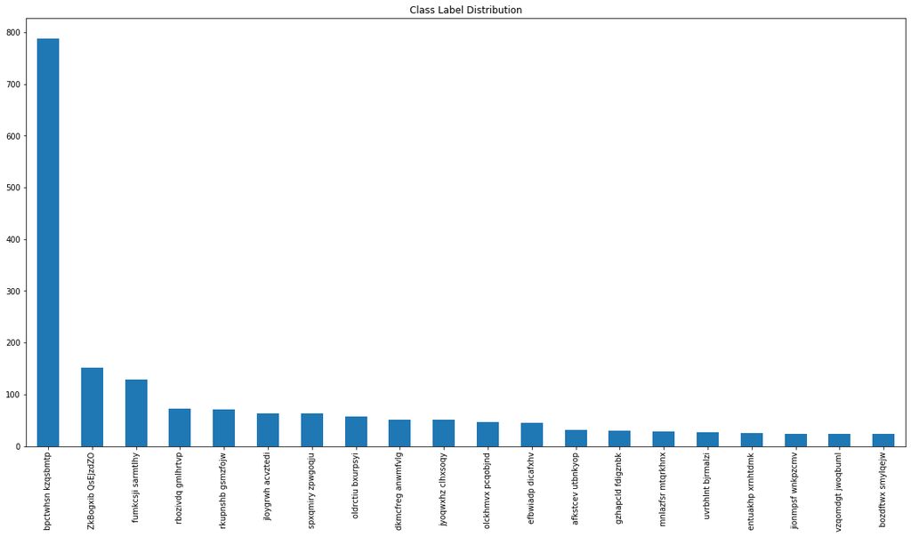

```python
tickets['Caller'].value_counts().sort_values(ascending=False).head(20).plot(kind='bar', figsize=(20,10), title='Class Label Distribution')
```

```python
#creating a new dataset to store only the required columns

cleaned_tickets = tickets[['CleanDescription', 'Assignment group']].copy()
```

```python
cleaned_tickets.head()
```

|  | CleanDescription | Assignment group |
| --- | --- | --- |
| 0 | login issue verified user details employee ma... | GRP_0 |
| 1 | outlook from hello team meetings skype meeti... | GRP_0 |
| 2 | cant log to vpn from cannot log to vpn best | GRP_0 |
| 3 | unable access tool page unable access tool page | GRP_0 |
| 4 | skype error skype error | GRP_0 |

```python
cleaned_tickets.describe()
```

|  | CleanDescription | Assignment group |
| --- | --- | --- |
| count | 8417 | 8417 |
| unique | 6839 | 74 |
| top | job job failed job scheduler from job jo... | GRP_0 |
| freq | 435 | 3934 |

- We see out of 8417 records only 6839 descriptions are only unique

```python
cleaned_tickets[cleaned_tickets['CleanDescription'].duplicated()].sort_values(by = 'CleanDescription', ascending=True)
```

|  | CleanDescription | Assignment group |
| --- | --- | --- |
| 7923 | lpal source system name lpal user ... | GRP_62 |
| 7102 | password reset password reset | GRP_0 |
| 7315 | password reset password reset | GRP_0 |
| 3892 | user unable tologin vpn connected the user sy... | GRP_0 |
| 3886 | user unable tologin vpn connected the user sy... | GRP_0 |
| ... | ... | ... |
| 1364 | windows password reset windows password reset | GRP_0 |
| 6052 | wireless outage again taiwan from hello wir... | GRP_4 |
| 5864 | wireless outage again taiwan from hello wir... | GRP_4 |
| 3297 | wireless outage again taiwan from hello wir... | GRP_4 |
| 7431 | zdsxmcwu thdjzolwronization issue zdsxmcwu thd... | GRP_0 |

1578 rows × 2 columns

```python
dup_tickets = cleaned_tickets.duplicated()
sum(dup_tickets)
```

```
1507
```

- We see a total of 1578 descriptions are duplicates of each other
- Out of 1578 tickets, 1507 tickets has been assigned same group thus, can be dropped safely
- This implies that 71 incidents have duplicate description but are assigned to different groups

```python
cleaned_tickets =cleaned_tickets.drop_duplicates()
```

```python
dup_tickets = cleaned_tickets.duplicated()
sum(dup_tickets)
```

```
0
```

```python
cleaned_tickets[cleaned_tickets['CleanDescription'].duplicated()].sort_values(by = 'CleanDescription', ascending=True)
```

|  | CleanDescription | Assignment group |
| --- | --- | --- |
| 7923 | lpal source system name lpal user ... | GRP_62 |
| 8234 | abended job job scheduler bkwin hostname inc ... | GRP_8 |
| 7070 | abended job job scheduler job from abended j... | GRP_8 |
| 7780 | abended job job scheduler job from abended j... | GRP_5 |
| 7118 | abended job job scheduler job from abended j... | GRP_47 |
| ... | ... | ... |
| 180 | unable connect vpn unable connect vpn | GRP_19 |
| 5935 | unable connect vpn unable connect vpn | GRP_50 |
| 3030 | unable launch outlook unable launch outlook | GRP_3 |
| 8271 | unable login ethics unable login ethics | GRP_23 |
| 5226 | unable login windows unable login windows | GRP_19 |

71 rows × 2 columns

- The above finding can be used to handle class imbalance

```python
# saving the final cleaned dataset in a new file for re-usability purpose

cleaned_tickets.to_csv('cleaned_data.csv', index=False, encoding='utf_8_sig')
```

```python
cleaned_tickets = pd.read_csv('cleaned_data.csv')  # read the data
cleaned_tickets.head()
```

|  | CleanDescription | Assignment group |
| --- | --- | --- |
| 0 | login issue verified user details employee ma... | GRP_0 |
| 1 | outlook from hello team meetings skype meeti... | GRP_0 |
| 2 | cant log to vpn from cannot log to vpn best | GRP_0 |
| 3 | unable access tool page unable access tool page | GRP_0 |
| 4 | skype error skype error | GRP_0 |

# Removing Caller names from description

```python
callers_list = input_data['Caller'].unique()
callers_list
```

```
array(['spxjnwir pjlcoqds', 'hmjdrvpb komuaywn', 'eylqgodm ybqkwiam', ...,
       'bjitvswa yrmugfnq', 'oybwdsgx oxyhwrfz', 'kqvbrspl jyzoklfx'],
      dtype=object)
```

```python
def removeCallerNames(indx, text):
    for callers in callers_list:
          callerlist = [xname for xname in callers.split()]
          for names in callerlist:
            text = text.replace(names,'')
    return text
```

```python
for i, row in enumerate(cleaned_tickets.itertuples(), 0):
    cleaned_tickets['CleanDescription'].iloc[i]=removeCallerNames(i, row.CleanDescription)
```

# Visualization

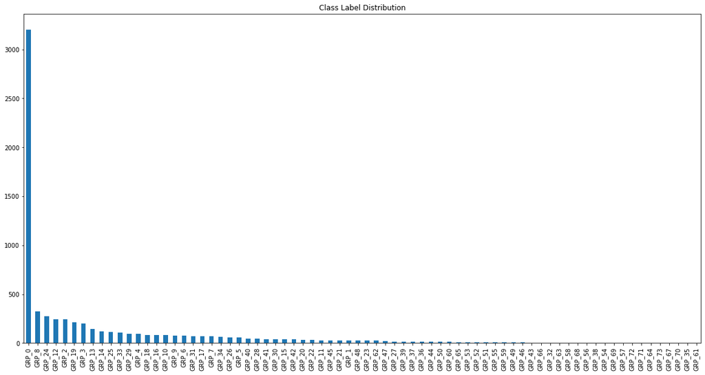

```python
cleaned_tickets['Assignment group'].value_counts().sort_values(ascending=False).plot(kind='bar', figsize=(20,10), title='Class Label Distribution')
```

## Word Cloud Visualization

```python
font = {'family': 'serif',
        'color':  'darkred',
        'weight': 'normal',
        'size': 16,
        }
```

```python
def visualize_wordCloud(data) :
    All_words = ""
    All_words += " ".join(data)
    wordcloud = WordCloud(background_color='white').generate(All_words) # width and height in the wordcloud attribute does not work
    plt.figure(figsize=(15,15))
    plt.title("WordCloud of Cleaned & Class Balanced Corpus Data", fontdict=font)
    plt.imshow(wordcloud, interpolation="bilinear")
    plt.axis("off")
    plt.show()
```

### 1) Group 0

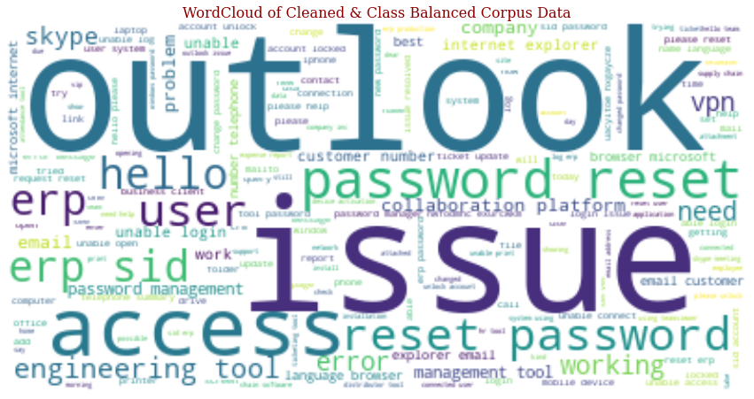

```python
visualize_wordCloud(cleaned_tickets[cleaned_tickets["Assignment group"].isin(['GRP_0'])].CleanDescription)
```

### 2) Group 8

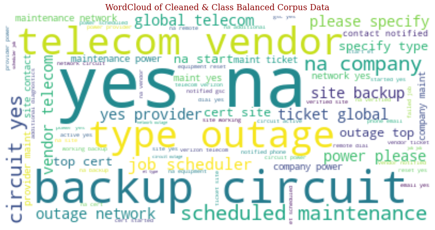

```python
visualize_wordCloud(cleaned_tickets[cleaned_tickets["Assignment group"].isin(['GRP_8'])].CleanDescription)
```

### 3) Group 24

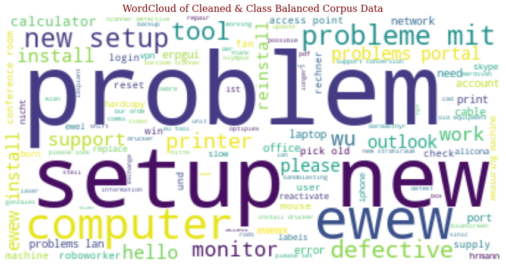

```python
visualize_wordCloud(cleaned_tickets[cleaned_tickets["Assignment group"].isin(['GRP_24'])].CleanDescription)
```

### 4) Group 12

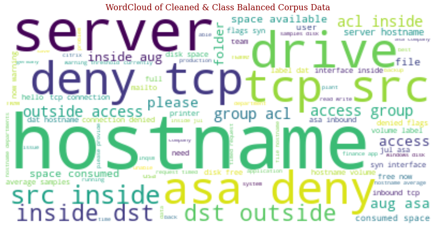

```python
visualize_wordCloud(cleaned_tickets[cleaned_tickets["Assignment group"].isin(['GRP_12'])].CleanDescription)
```

### 5) Group 2

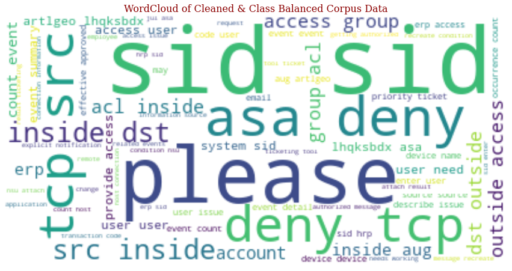

```python
visualize_wordCloud(cleaned_tickets[cleaned_tickets["Assignment group"].isin(['GRP_2'])].CleanDescription)
```

### 6) Other Groups other than the top 5

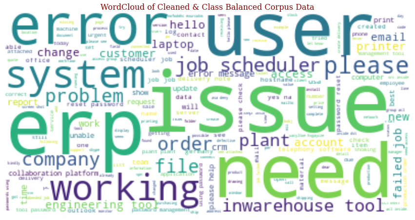

```python
visualize_wordCloud(cleaned_tickets[~cleaned_tickets["Assignment group"].isin(['GRP_0','GRP_8','GRP_24','GRP_12','GRP_2'])].CleanDescription)
```

# Lemmetisation and Word Tokenizer

```python
def removeNumbers(text):
    """ Removes integers """
    text = ''.join([i for i in text if not i.isdigit()])
    return text


#Replace Contractions

contraction_patterns = [ (r'won\'t', 'will not'),(r'didn\'t', 'did not'),(r'didnt', 'did not'), (r'can\'t', 'cannot'),(r'cant', 'cannot'), (r'i\'m', 'i am'), (r'ain\'t', 'is not'), (r'(\w+)\'ll', '\g<1> will'), (r'(\w+)n\'t', '\g<1> not'),
                         (r'(\w+)\'ve', '\g<1> have'), (r'(\w+)\'s', '\g<1> is'), (r'(\w+)\'re', '\g<1> are'), (r'(\w+)\'d', '\g<1> would'), (r'&', 'and'), (r'dammit', 'damn it'), (r'dont', 'do not'), (r'wont', 'will not') ]
def replaceContraction(text):
    patterns = [(re.compile(regex), repl) for (regex, repl) in contraction_patterns]
    for (pattern, repl) in patterns:
        (text, count) = re.subn(pattern, repl, text)
    return text

#Replace Negations with Antonym
def replace(word, pos=None):

    antonyms = set()
    for syn in wordnet.synsets(word, pos=pos):
        for lemma in syn.lemmas():
            for antonym in lemma.antonyms():
                antonyms.add(antonym.name())
    if len(antonyms) == 1:
        return antonyms.pop()
    else:
        return None
def replaceNegations(text):
    """ Finds "not" and antonym for the next word and if found, replaces not and the next word with the antonym """
    i, l = 0, len(text)
    words = []
    while i < l:
        word = text[i]
        if word == 'not' and i+1 < l:
            ant = replace(text[i+1])
            if ant:
                words.append(ant)
                i += 2
                continue
        words.append(word)
        i += 1
    return words

def antonym(text):
    tokens = nltk.word_tokenize(text)
    tokens = replaceNegations(tokens)
    text = " ".join(tokens)
    return text
#Remove Stopwords
stoplist = stopwords.words('english')
stoplist.remove('no')
stoplist.remove('not')
def stp_words(text):
    finalTokens = []
    tokens = nltk.word_tokenize(text)
    for w in tokens:
        if (w not in stoplist):
            finalTokens.append(w)
    text = " ".join(finalTokens)
    return text

#Remove mail related words
mail_words_list = ['hi','hello','com','gmail','cc','regards','thanks']
def mail_words(text):
    finalTokens = []
    tokens = nltk.word_tokenize(text)
    for w in tokens:
        if (w not in mail_words_list):
            finalTokens.append(w)
    text = " ".join(finalTokens)
    return text

#Lemmatization
stemmer = PorterStemmer() #set stemmer
lemmatizer = WordNetLemmatizer() # set lemmatizer

def nltk_tag_to_wordnet_tag(nltk_tag):
    if nltk_tag.startswith('J'):
        return wordnet.ADJ
    elif nltk_tag.startswith('V'):
        return wordnet.VERB
    elif nltk_tag.startswith('N'):
        return wordnet.NOUN
    elif nltk_tag.startswith('R'):
        return wordnet.ADV
    else:
        return None

def lemmatize_sentence(sentence):
    #tokenize the sentence and find the POS tag for each token
    nltk_tagged = nltk.pos_tag(nltk.word_tokenize(sentence))
    #tuple of (token, wordnet_tag)
    wordnet_tagged = map(lambda x: (x[0], nltk_tag_to_wordnet_tag(x[1])), nltk_tagged)
    lemmatized_sentence = []
    for word, tag in wordnet_tagged:
        if tag is None:
            #if there is no available tag, append the token as is
            lemmatized_sentence.append(word)
        else:
            #else use the tag to lemmatize the token
            lemmatized_sentence.append(lemmatizer.lemmatize(word, tag))
    return " ".join(lemmatized_sentence)

#Remove accented characters
def remove_accented_chars(text):
    text = unicodedata.normalize('NFKD', text).encode('ascii', 'ignore').decode('utf-8', 'ignore')
    return text
```

```python
import unicodedata
for index, row in cleaned_tickets.iterrows():

    proc_des = row['CleanDescription']

    proc_des = re.sub(r"\W", " ", proc_des, flags=re.I)
    proc_des = proc_des.replace('_',' ')

    #replace contractions
    proc_des = replaceContraction(proc_des)

    #remove accents
    proc_des = remove_accented_chars(proc_des)

    #convert to lower case
    proc_des = proc_des.lower()

    #replace negation with antonym - Skipping this for our case, as it couldnt process words like cannot
    #proc_des = antonym(proc_des)

    #remove stopwords
    proc_des = stp_words(proc_des)

    #remove mail related words
    proc_des = mail_words(proc_des)

    #lemmatization
    proc_des = lemmatize_sentence(proc_des)

    #create new column and add updated data
    cleaned_tickets.at[index, 'Clean Description - After']= proc_des
```

```python
cleaned_tickets.head()
```

|  | CleanDescription | Assignment group | Clean Description - After |
| --- | --- | --- | --- |
| 0 | login issue verified user details employee ma... | GRP_0 | login issue verify user detail employee manage... |
| 1 | outlook from hello team meetings skype meeti... | GRP_0 | outlook team meeting skype meeting etc not app... |
| 2 | cant log to vpn from cannot log to vpn best | GRP_0 | not log vpn not log vpn best |
| 3 | unable access tool page unable access tool page | GRP_0 | unable access tool page unable access tool page |
| 4 | skype error skype error | GRP_0 | skype error skype error |

- Tokenizer

```python
from tensorflow.keras.preprocessing.text import Tokenizer
MAX_NB_WORDS = 10000
t = Tokenizer(num_words=MAX_NB_WORDS, split=' ', char_level=False, oov_token=None, document_count=0)
t.fit_on_texts(cleaned_tickets['Clean Description - After'])
```

```python
!pip install sklearn
```

```python
from sklearn.feature_extraction.text import TfidfVectorizer

vectorizer = TfidfVectorizer()
X = vectorizer.fit_transform(cleaned_tickets['Clean Description - After'])
```

# 3: Deciding Models and Model Building

```python
from sklearn import metrics
from sklearn.linear_model import LogisticRegression
from sklearn.neighbors import KNeighborsClassifier
from sklearn.ensemble import RandomForestClassifier,AdaBoostClassifier,BaggingClassifier,GradientBoostingClassifier
from sklearn.naive_bayes import MultinomialNB
from sklearn.metrics import accuracy_score,f1_score,recall_score,precision_score, confusion_matrix, classification_report
from sklearn.svm import SVC
from sklearn.tree import DecisionTreeClassifier
from sklearn import model_selection
```

```python
def fit_n_print(model, X_train, X_test, y_train, y_test):
    model.fit(X_train, y_train)
    pred = model.predict(X_test)
    score = model.score(X_test, y_test)
    return score  # return accuracy metrics
```

```python
models=[]
models.append(('LogisticRegression',LogisticRegression(solver = 'liblinear')))
models.append(('knn',KNeighborsClassifier()))
models.append(('SVC',SVC(gamma = 'auto', kernel= 'poly', degree=2)))
models.append(('Naive Bayes',MultinomialNB()))
models.append(("Decision_tree",DecisionTreeClassifier(criterion = 'entropy')))
models.append(("Random_Forest",RandomForestClassifier(criterion = 'entropy')))
models.append(("Ada_Boost",AdaBoostClassifier( n_estimators= 20)))
models.append(("Bagging",BaggingClassifier(n_estimators=74, max_samples= .7, bootstrap=True)))
models.append(("Gradient_Boosting",GradientBoostingClassifier(n_estimators = 10, learning_rate = 0.05)))
```

- Spliting the data set into 75:25 ratio with target as 'Assignment group'

```python
train_x, test_x, train_y, test_y = model_selection.train_test_split(X, cleaned_tickets['Assignment group'], test_size=0.25, random_state=42)
```

- Fitting into the model

```python
result1 = pd.DataFrame({'Model':[],'Accuracy':[]})
for name,model in models:
    accuracy = fit_n_print(model, train_x, test_x, train_y, test_y )
    result1 = result1.append(pd.Series({'Model':name, 'Accuracy':accuracy}), ignore_index=True)
print(result1)
```

```
                Model  Accuracy
0  LogisticRegression  0.567130
1                 knn  0.534722
2                 SVC  0.467014
3         Naive Bayes  0.505208
4       Decision_tree  0.491319
5       Random_Forest  0.568287
6           Ada_Boost  0.484954
7             Bagging  0.592014
8   Gradient_Boosting  0.524306
```

# Handling Class Imbalance

```python
group_frequency = dict(cleaned_tickets['Assignment group'].value_counts())
```

```python
group_df = pd.DataFrame.from_dict(group_frequency, orient='index', columns=['frequency'])
group_df['percent representation'] = group_df['frequency'] / group_df['frequency'].sum()
group_df['cumulative percentage'] = group_df['percent representation'].cumsum(axis = 0)
group_df.head(35)
```

|  | frequency | percent representation | cumulative percentage |
| --- | --- | --- | --- |
| GRP_0 | 3204 | 0.463676 | 0.463676 |
| GRP_8 | 327 | 0.047323 | 0.510999 |
| GRP_24 | 277 | 0.040087 | 0.551085 |
| GRP_12 | 245 | 0.035456 | 0.586541 |
| GRP_2 | 241 | 0.034877 | 0.621418 |
| GRP_19 | 214 | 0.030970 | 0.652388 |
| GRP_3 | 200 | 0.028944 | 0.681331 |
| GRP_13 | 142 | 0.020550 | 0.701881 |
| GRP_14 | 118 | 0.017077 | 0.718958 |
| GRP_25 | 116 | 0.016787 | 0.735745 |
| GRP_33 | 107 | 0.015485 | 0.751230 |
| GRP_29 | 97 | 0.014038 | 0.765268 |
| GRP_4 | 96 | 0.013893 | 0.779161 |
| GRP_18 | 86 | 0.012446 | 0.791606 |
| GRP_16 | 85 | 0.012301 | 0.803907 |
| GRP_10 | 82 | 0.011867 | 0.815774 |
| GRP_9 | 79 | 0.011433 | 0.827207 |
| GRP_6 | 77 | 0.011143 | 0.838350 |
| GRP_7 | 68 | 0.009841 | 0.848191 |
| GRP_31 | 68 | 0.009841 | 0.858032 |
| GRP_17 | 68 | 0.009841 | 0.867873 |
| GRP_34 | 62 | 0.008973 | 0.876845 |
| GRP_26 | 56 | 0.008104 | 0.884949 |
| GRP_5 | 56 | 0.008104 | 0.893054 |
| GRP_40 | 45 | 0.006512 | 0.899566 |
| GRP_28 | 44 | 0.006368 | 0.905933 |
| GRP_41 | 40 | 0.005789 | 0.911722 |
| GRP_30 | 39 | 0.005644 | 0.917366 |
| GRP_15 | 38 | 0.005499 | 0.922865 |
| GRP_42 | 37 | 0.005355 | 0.928220 |
| GRP_20 | 36 | 0.005210 | 0.933430 |
| GRP_22 | 31 | 0.004486 | 0.937916 |
| GRP_11 | 30 | 0.004342 | 0.942258 |
| GRP_45 | 29 | 0.004197 | 0.946454 |
| GRP_1 | 28 | 0.004052 | 0.950507 |

- With top 35 groups we are able to reach cumulative of 95%

```python
groups = cleaned_tickets.groupby(['Assignment group'])
misc_group=[]
for grp in cleaned_tickets['Assignment group'].unique():
      if(groups.get_group(grp).shape[0]<35):
        misc_group.append(grp)
print('misc_group which have under 35 samples are {} '.format(len(misc_group)))
cleaned_tickets['Assignment group - After']=cleaned_tickets['Assignment group'].apply(lambda x : 'misc_grp' if x in misc_group else x)
```

```
misc_group which have under 35 samples are 43
```

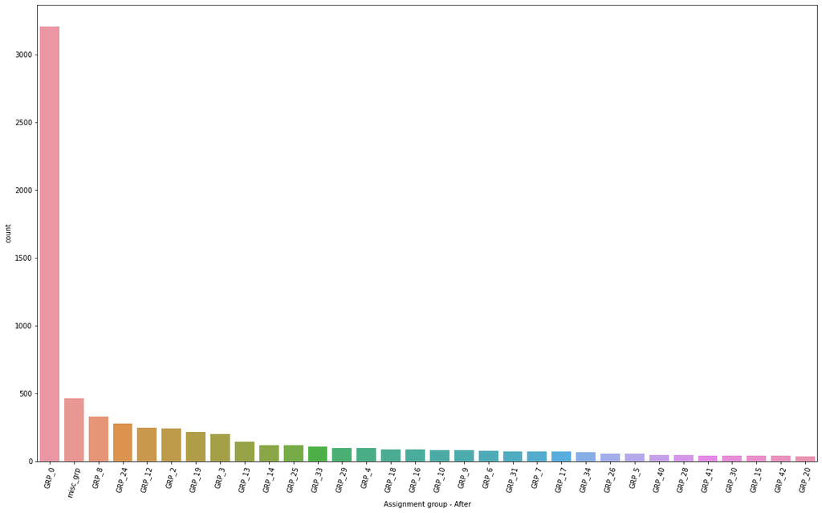

```python
df_desc = cleaned_tickets['Assignment group - After'].value_counts().sort_values(ascending=False).index
plt.figure(figsize= (20,12))
plt.xticks(rotation=75)
sns.countplot(x='Assignment group - After', data=cleaned_tickets, order=df_desc)
```

# Model Building with balanced grouping

- Spliting the data set into 75:25 ratio with target as 'Assignment group - After'

```python
train_x1, test_x1, train_y1, test_y1 = model_selection.train_test_split(X, cleaned_tickets['Assignment group - After'], test_size=0.25, random_state=42)
```

```python
models_1=[]
models_1.append(('LogisticRegression',LogisticRegression(solver = 'liblinear')))
models_1.append(('knn',KNeighborsClassifier()))
models_1.append(('SVC',SVC(gamma = 'auto', kernel= 'poly', degree=2)))
models_1.append(('Naive Bayes',MultinomialNB()))
models_1.append(("Decision_tree",DecisionTreeClassifier(criterion = 'entropy')))
models_1.append(("Random_Forest",RandomForestClassifier(criterion = 'entropy')))
models_1.append(("Ada_Boost",AdaBoostClassifier( n_estimators= 20)))
models_1.append(("Bagging",BaggingClassifier(n_estimators=74, max_samples= .7, bootstrap=True)))
models_1.append(("Gradient_Boosting",GradientBoostingClassifier(n_estimators = 10, learning_rate = 0.05)))
```

```python
result2 = pd.DataFrame({'Model':[],'Accuracy':[]})
for name,model in models_1:
    accuracy = fit_n_print(model, train_x1, test_x1, train_y1, test_y1 )
    result2 = result2.append(pd.Series({'Model':name, 'Accuracy':accuracy }), ignore_index=True)
print(result2)
```

```
                Model  Accuracy
0  LogisticRegression  0.574074
1                 knn  0.532986
2                 SVC  0.467014
3         Naive Bayes  0.507523
4       Decision_tree  0.490741
5       Random_Forest  0.572917
6           Ada_Boost  0.495370
7             Bagging  0.587384
8   Gradient_Boosting  0.531829
```

### Observation

- There is no much difference in accuracy even after handling the class imbalance
- All the models are having accuracy between 45% to 60%

# 4: How to improve your model performance?

1. **We have used second approach of handling class imbalance**
2. But did not see much improvement, thus **we can further do hyper parameter tuning**
3. And further can go ahead and use **Bi-directional lstm** as it is one of the best models for text and sentiment analysis,

### These steps will be covered in the final submission

-